# Pandas Review Homework

Import pandas

```python
import pandas as pd
```

## 1. Make a data frame from a Python dictionary.

Create a Python dictionary containing

- the names of four of your friends (real or imaginary)
- their ages
- the year they started college
- their majors

```python
friends = {
    "Ava Martinez": {"age": 21, "year_started_college": 2023, "major": "Biology"},
    "Liam Chen": {"age": 22, "year_started_college": 2022, "major": "Computer Science"},
    "Noah Johnson": {"age": 20, "year_started_college": 2024, "major": "Mechanical Engineering"},
    "Sofia Patel": {"age": 23, "year_started_college": 2021, "major": "Psychology"}}
```

Make a pandas data frame from your dictionary.

```python
df = pd.DataFrame.from_dict(friends, orient="index")
df.reset_index(inplace=True)
df.rename(columns={"index": "name"}, inplace=True)
```

Show your new data frame.

```python
df
```

|  | name | age | year_started_college | major |
| --- | --- | --- | --- | --- |
| 0 | Ava Martinez | 21 | 2023 | Biology |
| 1 | Liam Chen | 22 | 2022 | Computer Science |
| 2 | Noah Johnson | 20 | 2024 | Mechanical Engineering |
| 3 | Sofia Patel | 23 | 2021 | Psychology |

Fetch the ages of all your friends.

```python
df['age']
```

```
0    21
1    22
2    20
3    23
Name: age, dtype: int64
```

Fetch the name of your fourth friend.

```python
df['name'][3]
```

```
'Sofia Patel'
```

Fetch the age of your third friend.

```python
df['age'][2]
```

```
20
```

Compute and show the average age of your friends.

```python
df["age"].mean()
```

```
21.5
```

## 2. Find a table of data on Wikipedia and import it.

Go to Widepedia and find a table of data. It can be anything you want.

In the cell below, import the data and display it (first and last five rows).

```python
wiki = pd.read_clipboard()
print(wiki.head(), wiki.tail())
```

```
   Census    Pop.  Note      %±
0    1850     629   NaN       —
1    1860   3,494   NaN  455.5%
2    1870   4,428   NaN   26.7%
3    1880  11,013   NaN  148.7%
4    1890  14,575   NaN   32.3%     Census     Pop.  Note     %±
13    1980  345,890   NaN  36.4%
14    1990  465,622   NaN  34.6%
15    2000  656,562   NaN  41.0%
16    2010  790,390   NaN  20.4%
17    2020  961,855   NaN  21.7%
```

## 3. Load the RMS titanic data and export a subset of columns

Load the titanic data, make a new `DataFrame` of the fare paid and the survival columns, and export it as a `.csv` file.

```python
In [2]: titanic = pd.read_csv("data/titanic.csv")

fare_survival = titanic[["Fare", "Survived"]]
fare_survival.to_csv("fare_survival.csv", index=False)
```

Import your new `.csv` file into a new `DataFrame` and show it (first and last five rows).

```python
fare_survival_new = pd.read_csv("fare_survival.csv")
fare_survival_new.head()
```

|  | Fare | Survived |
| --- | --- | --- |
| 0 | 7.2500 | 0 |
| 1 | 71.2833 | 1 |
| 2 | 7.9250 | 1 |
| 3 | 53.1000 | 1 |
| 4 | 8.0500 | 0 |

## 4. Fetch specific rows of data of the titanic data

Fetch all the second class passengers of the titanic data and put them in a new `DataFrame` and show it.

```python
second_class = titanic[titanic["Pclass"] == 2]

second_class
```

|  | PassengerId | Survived | Pclass | Name | Sex | Age | SibSp | Parch | Ticket | Fare | Cabin | Embarked |
| --- | --- | --- | --- | --- | --- | --- | --- | --- | --- | --- | --- | --- |
| 9 | 10 | 1 | 2 | Nasser, Mrs. Nicholas (Adele Achem) | female | 14.0 | 1 | 0 | 237736 | 30.0708 | NaN | C |
| 15 | 16 | 1 | 2 | Hewlett, Mrs. (Mary D Kingcome) | female | 55.0 | 0 | 0 | 248706 | 16.0000 | NaN | S |
| 17 | 18 | 1 | 2 | Williams, Mr. Charles Eugene | male | NaN | 0 | 0 | 244373 | 13.0000 | NaN | S |
| 20 | 21 | 0 | 2 | Fynney, Mr. Joseph J | male | 35.0 | 0 | 0 | 239865 | 26.0000 | NaN | S |
| 21 | 22 | 1 | 2 | Beesley, Mr. Lawrence | male | 34.0 | 0 | 0 | 248698 | 13.0000 | D56 | S |
| ... | ... | ... | ... | ... | ... | ... | ... | ... | ... | ... | ... | ... |
| 866 | 867 | 1 | 2 | Duran y More, Miss. Asuncion | female | 27.0 | 1 | 0 | SC/PARIS 2149 | 13.8583 | NaN | C |
| 874 | 875 | 1 | 2 | Abelson, Mrs. Samuel (Hannah Wizosky) | female | 28.0 | 1 | 0 | P/PP 3381 | 24.0000 | NaN | C |
| 880 | 881 | 1 | 2 | Shelley, Mrs. William (Imanita Parrish Hall) | female | 25.0 | 0 | 1 | 230433 | 26.0000 | NaN | S |
| 883 | 884 | 0 | 2 | Banfield, Mr. Frederick James | male | 28.0 | 0 | 0 | C.A./SOTON 34068 | 10.5000 | NaN | S |
| 886 | 887 | 0 | 2 | Montvila, Rev. Juozas | male | 27.0 | 0 | 0 | 211536 | 13.0000 | NaN | S |

184 rows × 12 columns

Fetch all the first and third class passengers, put them in a new `DataFrame`, and show it.

```python
first_third = titanic[titanic["Pclass"].isin([1, 3])]

first_third
```

|  | PassengerId | Survived | Pclass | Name | Sex | Age | SibSp | Parch | Ticket | Fare | Cabin | Embarked |
| --- | --- | --- | --- | --- | --- | --- | --- | --- | --- | --- | --- | --- |
| 0 | 1 | 0 | 3 | Braund, Mr. Owen Harris | male | 22.0 | 1 | 0 | A/5 21171 | 7.2500 | NaN | S |
| 1 | 2 | 1 | 1 | Cumings, Mrs. John Bradley (Florence Briggs Th... | female | 38.0 | 1 | 0 | PC 17599 | 71.2833 | C85 | C |
| 2 | 3 | 1 | 3 | Heikkinen, Miss. Laina | female | 26.0 | 0 | 0 | STON/O2. 3101282 | 7.9250 | NaN | S |
| 3 | 4 | 1 | 1 | Futrelle, Mrs. Jacques Heath (Lily May Peel) | female | 35.0 | 1 | 0 | 113803 | 53.1000 | C123 | S |
| 4 | 5 | 0 | 3 | Allen, Mr. William Henry | male | 35.0 | 0 | 0 | 373450 | 8.0500 | NaN | S |
| ... | ... | ... | ... | ... | ... | ... | ... | ... | ... | ... | ... | ... |
| 885 | 886 | 0 | 3 | Rice, Mrs. William (Margaret Norton) | female | 39.0 | 0 | 5 | 382652 | 29.1250 | NaN | Q |
| 887 | 888 | 1 | 1 | Graham, Miss. Margaret Edith | female | 19.0 | 0 | 0 | 112053 | 30.0000 | B42 | S |
| 888 | 889 | 0 | 3 | Johnston, Miss. Catherine Helen "Carrie" | female | NaN | 1 | 2 | W./C. 6607 | 23.4500 | NaN | S |
| 889 | 890 | 1 | 1 | Behr, Mr. Karl Howell | male | 26.0 | 0 | 0 | 111369 | 30.0000 | C148 | C |
| 890 | 891 | 0 | 3 | Dooley, Mr. Patrick | male | 32.0 | 0 | 0 | 370376 | 7.7500 | NaN | Q |

707 rows × 12 columns

## 5. Plot some Titanic data

First, import `matplotlib`

```python
import matplotlib.pyplot as plt
```

### 5.a - Scatter plot

Make a scatter plot of fare vs. ticket class (`Pclass`) – seems like these should be perfectly related, but...

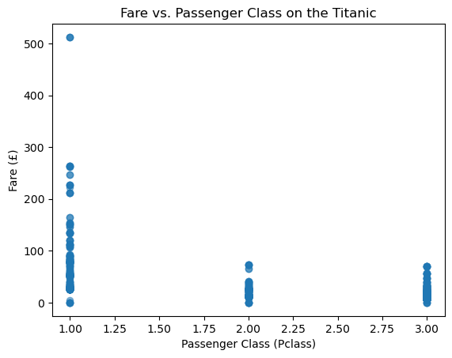

```python
plt.scatter(titanic["Pclass"], titanic["Fare"], alpha=0.5)
plt.xlabel("Passenger Class (Pclass)")
plt.ylabel("Fare (£)")
plt.title("Fare vs. Passenger Class on the Titanic")
plt.show()
```

### 5.b - Distribution plot (challenging!)

Plot the distributions of fare paid for survivors and deceased in a way that makes for a good visual comparison.

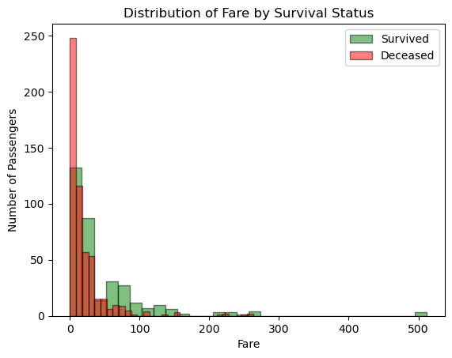

```python
fares_survived = titanic.loc[titanic["Survived"] == 1, "Fare"]
fares_deceased = titanic.loc[titanic["Survived"] == 0, "Fare"]

# Plot overlapping histograms
plt.hist(fares_survived, bins=30, alpha=0.5, label="Survived", color="g", edgecolor="k")
plt.hist(fares_deceased, bins=30, alpha=0.5, label="Deceased", color="r", edgecolor="k")

plt.xlabel("Fare")
plt.ylabel("Number of Passengers")
plt.title("Distribution of Fare by Survival Status")
plt.legend()
plt.show()
```

## 6. Calculate new columns

### 6.a - Compute total number of relatives

Create a new column in your titanic `DataFrame` quantifying the total number of relatives on board (siblings + parents – the number of siblings are in `SibSp` and the number of parents are in `Parch`).

```python
titanic["RelativesOnBoard"] = titanic["SibSp"] + titanic["Parch"]
titanic[["SibSp", "Parch", "RelativesOnBoard"]].head()
```

|  | SibSp | Parch | RelativesOnBoard |
| --- | --- | --- | --- |
| 0 | 1 | 0 | 1 |
| 1 | 1 | 0 | 1 |
| 2 | 0 | 0 | 0 |
| 3 | 1 | 0 | 1 |
| 4 | 0 | 0 | 0 |

### 6.b - Did a person have any relatives on board?

Add another column – a Boolean column – indicating whether each person had any relatives on board.

```python
titanic["HasRelatives"] = titanic["RelativesOnBoard"] > 0
titanic[["RelativesOnBoard", "HasRelatives"]].head()
```

|  | RelativesOnBoard | HasRelatives |
| --- | --- | --- |
| 0 | 1 | True |
| 1 | 1 | True |
| 2 | 0 | False |
| 3 | 1 | True |
| 4 | 0 | False |

## 7. Computing descriptive statistics

### 7.a - Compute a mean for a column

Compute the proportion of survivors of the RMS Titanic. **Hint**: the coding of `Survival` as 0 or 1 really works to our advantage here: the proportion of survivors in any group is easily computed using a common statistical function. The 7.a section header should also give you a big clue!

```python
titanic["Survived"].mean()
```

```
0.3838383838383838
```

### 7.a - Compute a mean for a subset of data

Compute the proportion of survivors for the females on the RMS Titanic (you can do this in one go, or two steps, using an intermediate object containing just the female data).

```python
titanic.loc[titanic["Sex"] == "female", "Survived"].mean()
```

```
0.7420382165605095
```

### 7.b - Compute statistics by group

Compute the proportion of female vs. male survivors of the RMS Titanic.

```python
titanic.groupby("Sex")["Survived"].mean()
```

```
Sex
female    0.742038
male      0.188908
Name: Survived, dtype: float64
```

Now compute the proportion of female vs. male survivors of the RMS Titanic, *along with the* *s**tandard* *e**rror of the* *m**ean*. The **bold** type should give you a hint about the name of the method to compute the standard error. To do this, you'll need to combine the `groupby()` and `agg()` methods!

```python
titanic.groupby("Sex")["Survived"].agg(["mean", "sem"])
```

| Sex | mean | sem |
| --- | --- | --- |
| female | 0.742038 | 0.02473 |
| male | 0.188908 | 0.01631 |

What does this tell you about gender roles when the RMS Titanic was sunk?

Women were deemed more important to save.

Compute the proportion of survivors by cabin class and their standard error.

```python
titanic.groupby("Pclass")["Survived"].agg(["mean", "sem"])
```

| Pclass | mean | sem |
| --- | --- | --- |
| 1 | 0.629630 | 0.032934 |
| 2 | 0.472826 | 0.036906 |
| 3 | 0.242363 | 0.019358 |

What does this tell you about socio-economic status when the RMS Titanic was sunk?

Those who paid more were more likely to survive.